# telecom_revenue

My name is **John Dickson** (https://hub.tripleten.com/u/13efa053) and today I'll be reviewing your project!

You’ll find specific notes inside the project file, marked green, yellow or red.

**Note:** Please do not remove or change my comments - they will help me in the future reviews and will make the process smoother for both of us.

**✅ Reviewer's comment**

Such comment will mark efficient solutions and good ideas that can be used in other projects. It will also point at the document formatting, comments, and analysis.

**⚠️ Reviewer's comment**

The parts marked with yellow comments indicate that there is room for optimisation. Though the correction is not necessary it is good if you implement it.

**⛔️ Reviewer's comment**

If you see such a comment, it means that there is a problem that needs to be fixed. Please note that I won't be able to accept your project until the issue is resolved.

You are also welcome to leave your own comments, explain any changes you've made, or ask questions by marking them with a different color. You can use the example below (copy the code and use it in a Markdown-type cell):

```
<div class="alert alert-info"; style="border-left: 7px solid blue">
<b>Student’s Comment</b>
```

It will appear like this:

**Student’s Comment**

📌 Please feel free to schedule a 1:1 sessions with our tutors, join daily coworking sessions, or ask questions on TripleTen Hub if you need assistance 😉

V2

**What Was Great:**

- Data was checked, fixed, and enriched correctly
- Data aggregation is good
- Merging is done correctly
- Calculations for monthly revenue is done well
- Graphs are well presented

**What could be improved:**

- Use markdown cells for analysis. Adding 2 spaces to the end of a line before going to a new line makes it display correctly on separate lines as well.

Great work on this project Felimon! I see that all the issues that you encountered on your previous submission have been fixed!!

# Which one is a better plan?

You work as an analyst for the telecom operator Megaline. The company offers its clients two prepaid plans, Surf and Ultimate. The commercial department wants to know which of the plans brings in more revenue in order to adjust the advertising budget.

You are going to carry out a preliminary analysis of the plans based on a relatively small client selection. You'll have the data on 500 Megaline clients: who the clients are, where they're from, which plan they use, and the number of calls they made and text messages they sent in 2018. Your job is to analyze the clients' behavior and determine which prepaid plan brings in more revenue.

**Reviewer's comment**

The bracketed instructional comments were not removed — those should be deleted before final submission (they were meant as instructor guidance, not content for the delivered report).

## Initialization

```python
# Loading all the libraries
import pandas as pd
import numpy as np
from scipy import stats
import matplotlib.pyplot as plt
```

## Load data

```python
# Load the data files into different DataFrames
users = pd.read_csv('/datasets/megaline_users.csv')
calls = pd.read_csv('/datasets/megaline_calls.csv')
messages = pd.read_csv('/datasets/megaline_messages.csv')
internet = pd.read_csv('/datasets/megaline_internet.csv')
plans = pd.read_csv('/datasets/megaline_plans.csv')
```

## Plans

```python
# Print the general/summary information about the plans' DataFrame

plans.info()
print(plans.head())
```

```
<class 'pandas.core.frame.DataFrame'>
RangeIndex: 2 entries, 0 to 1
Data columns (total 8 columns):
 #   Column                 Non-Null Count  Dtype
---  ------                 --------------  -----
 0   messages_included      2 non-null      int64
 1   mb_per_month_included  2 non-null      int64
 2   minutes_included       2 non-null      int64
 3   usd_monthly_pay        2 non-null      int64
 4   usd_per_gb             2 non-null      int64
 5   usd_per_message        2 non-null      float64
 6   usd_per_minute         2 non-null      float64
 7   plan_name              2 non-null      object
dtypes: float64(2), int64(5), object(1)
memory usage: 256.0+ bytes
   messages_included  mb_per_month_included  minutes_included  \
0                 50                  15360               500
1               1000                  30720              3000

   usd_monthly_pay  usd_per_gb  usd_per_message  usd_per_minute plan_name
0               20          10             0.03            0.03      surf
1               70           7             0.01            0.01  ultimate
```

```python
# Print a sample of data for plans

print(plans)
```

```
   messages_included  mb_per_month_included  minutes_included  \
0                 50                  15360               500
1               1000                  30720              3000

   usd_monthly_pay  usd_per_gb  usd_per_message  usd_per_minute plan_name
0               20          10             0.03            0.03      surf
1               70           7             0.01            0.01  ultimate
```

Observatoins from Plans Data

STRUCTURE: 2 rows of either the surf or the ultimate plan 8 columns complete with information No missing values

DATA TYPES: 'messages_included', ''mb_per_month', 'minutes_included': int64 (plan limits) 'usd_monthly_pay': int64 (base monthly fee)) 'usd_per_gb' 'usd_per_message', 'usd_per_minute': float64 (exceeding rates) 'plan_name': object (string)

NO FIXES NEEDED: data types are appropriate no missing values data is consistent in referencing values

**Reviewer's comment**

## Fix data

```python
# official plans do not need fixing unless the plans themselves change.
```

## Enrich data

```python
# official plans do not need enriching at the moment.
# two rows: the surf plan and the ultimate plan
```

## Users

```python
# Print the general/summary information about the users' DataFrame

users.info()
```

```
<class 'pandas.core.frame.DataFrame'>
RangeIndex: 500 entries, 0 to 499
Data columns (total 8 columns):
 #   Column      Non-Null Count  Dtype
---  ------      --------------  -----
 0   user_id     500 non-null    int64
 1   first_name  500 non-null    object
 2   last_name   500 non-null    object
 3   age         500 non-null    int64
 4   city        500 non-null    object
 5   reg_date    500 non-null    object
 6   plan        500 non-null    object
 7   churn_date  34 non-null     object
dtypes: int64(2), object(6)
memory usage: 31.4+ KB
```

```python
# Print a sample of data for users

print(users.head())
print(users.sample(5, random_state = 41))
```

```
   user_id first_name  last_name  age                                   city  \
0     1000   Anamaria      Bauer   45  Atlanta-Sandy Springs-Roswell, GA MSA
1     1001     Mickey  Wilkerson   28        Seattle-Tacoma-Bellevue, WA MSA
2     1002     Carlee    Hoffman   36   Las Vegas-Henderson-Paradise, NV MSA
3     1003   Reynaldo    Jenkins   52                          Tulsa, OK MSA
4     1004    Leonila   Thompson   40        Seattle-Tacoma-Bellevue, WA MSA

     reg_date      plan churn_date
0  2018-12-24  ultimate        NaN
1  2018-08-13      surf        NaN
2  2018-10-21      surf        NaN
3  2018-01-28      surf        NaN
4  2018-05-23      surf        NaN
     user_id first_name last_name  age  \
196     1196       Noel    Dawson   46
```

[output cut: 18 more lines]

Observations of Users Data

500 users with 8 columns 'churn_date' NaN values indicate active users 'reg_date' is stored as string, not datetime format 'surf' and 'ultimate' plans users from multiple cities

CONVERSIONS NEEDED: 'reg_date' to datetime for analysis 'churn_date' to datetime (preserve NaN for active users)

**Reviewer's comment**

### Fix Data

```python
# reg_date should be converted to datetime for manipulation and comprehension.
# churn_date also needs conversion to datetime for manipulation and comprehension.

users['reg_date'] = pd.to_datetime(users['reg_date'])
users['churn_date'] = pd.to_datetime(users['churn_date'])

# verify ability to manipulate reg_date and churn_date in datetime

print(users.info())
print(users.head())
```

```
<class 'pandas.core.frame.DataFrame'>
RangeIndex: 500 entries, 0 to 499
Data columns (total 8 columns):
 #   Column      Non-Null Count  Dtype
---  ------      --------------  -----
 0   user_id     500 non-null    int64
 1   first_name  500 non-null    object
 2   last_name   500 non-null    object
 3   age         500 non-null    int64
 4   city        500 non-null    object
 5   reg_date    500 non-null    datetime64[ns]
 6   plan        500 non-null    object
 7   churn_date  34 non-null     datetime64[ns]
dtypes: datetime64[ns](2), int64(2), object(4)
memory usage: 31.4+ KB
None
   user_id first_name  last_name  age                                   city  \
0     1000   Anamaria      Bauer   45  Atlanta-Sandy Springs-Roswell, GA MSA
1     1001     Mickey  Wilkerson   28        Seattle-Tacoma-Bellevue, WA MSA
2     1002     Carlee    Hoffman   36   Las Vegas-Henderson-Paradise, NV MSA
3     1003   Reynaldo    Jenkins   52                          Tulsa, OK MSA
4     1004    Leonila   Thompson   40        Seattle-Tacoma-Bellevue, WA MSA

    reg_date      plan churn_date
0 2018-12-24  ultimate        NaT
1 2018-08-13      surf        NaT
2 2018-10-21      surf        NaT
3 2018-01-28      surf        NaT
4 2018-05-23      surf        NaT
```

### Enrich Data

```python
# no significant enrichment necessary at the moment
# description:
# users table of 500 customer records, registration dates throughout 2018.
# churn_date column contains NaN values overlooking active customers.
```

## Calls

```python
# Print the general/summary information about the calls' DataFrame

calls.info()
```

```
<class 'pandas.core.frame.DataFrame'>
RangeIndex: 137735 entries, 0 to 137734
Data columns (total 4 columns):
 #   Column     Non-Null Count   Dtype
---  ------     --------------   -----
 0   id         137735 non-null  object
 1   user_id    137735 non-null  int64
 2   call_date  137735 non-null  object
 3   duration   137735 non-null  float64
dtypes: float64(1), int64(1), object(2)
memory usage: 4.2+ MB
```

```python
# Print a sample of data for calls

print(calls.head())
print(calls.sample(5, random_state = 41))
print(calls['duration'].describe())
```

```
         id  user_id   call_date  duration
0   1000_93     1000  2018-12-27      8.52
1  1000_145     1000  2018-12-27     13.66
2  1000_247     1000  2018-12-27     14.48
3  1000_309     1000  2018-12-28      5.76
4  1000_380     1000  2018-12-30      4.22
              id  user_id   call_date  duration
32735    1123_93     1123  2018-10-20      6.94
35056   1132_418     1132  2018-11-16     14.43
131676  1472_803     1472  2018-06-14      0.00
21893    1081_92     1081  2018-09-07      3.03
74933   1264_241     1264  2018-05-21      2.54
count    137735.000000
mean          6.745927
std           5.839241
min           0.000000
25%           1.290000
50%           5.980000
75%          10.690000
max          37.600000
Name: duration, dtype: float64
```

Observations from Calls Data

STRUCTURE: 137,735 calls with 4 columns no missing values

DATA TYPES: 'id': object, 'user_id': int64, 'call_date': object, 'duration': float64

ISSUES FIXED: zero-duration calls ommitted 'call_date' needs conversion from object to datetime64 rounded durations up to the next miinute

RESULT: datetime ready for monthly aggregation rounding for billing charges no revenue for zero-duration

### Fix data

```python
# convert call_date to datetime for manipulation and comprehension

calls['call_date'] = pd.to_datetime(calls['call_date'])

# apply megaline's rounding to duration - to the next minute
# exempt zero duration calls

calls['duration'] = np.ceil(calls['duration'])

# filter rows with zero-duration calls

print(f"Before: {len(calls)} calls")
calls = calls[calls['duration'] > 0].copy()
print(f"After: {len(calls)} calls (removed zero-duration)")
# verify call_date datetime and duration rounding

print(calls.info())
print(calls.head())
print(calls['duration'].describe())
```

```
Before: 137735 calls
After: 110901 calls (removed zero-duration)
<class 'pandas.core.frame.DataFrame'>
Int64Index: 110901 entries, 0 to 137734
Data columns (total 4 columns):
 #   Column     Non-Null Count   Dtype
---  ------     --------------   -----
 0   id         110901 non-null  object
 1   user_id    110901 non-null  int64
 2   call_date  110901 non-null  datetime64[ns]
 3   duration   110901 non-null  float64
dtypes: datetime64[ns](1), float64(1), int64(1), object(1)
memory usage: 4.2+ MB
None
         id  user_id  call_date  duration
0   1000_93     1000 2018-12-27       9.0
1  1000_145     1000 2018-12-27      14.0
2  1000_247     1000 2018-12-27      15.0
3  1000_309     1000 2018-12-28       6.0
4  1000_380     1000 2018-12-30       5.0
count    110901.000000
mean          8.875907
std           5.355181
min           1.000000
25%           5.000000
50%           8.000000
75%          12.000000
max          38.000000
Name: duration, dtype: float64
```

**Reviewer's comment**

### Enrich data

```python
# no significant enrichment needed at the moment
# descsription:
# calls dataframes containe 137,735 call records with no missing values.
# call_date and duration columns require conversion for manipulation and comprehension
# duration column requires application of megaline's billing rules
# zero-duration calls must be dropped throughout 2018.

# extracting months for all usage tables - calls, messages, and internet
# add the month column to all usage tables for aggregation of monthly statistics

calls['month'] = calls['call_date'].dt.to_period('M')
calls.info()
print('Month columns added to all usage tables')
```

```
<class 'pandas.core.frame.DataFrame'>
Int64Index: 110901 entries, 0 to 137734
Data columns (total 5 columns):
 #   Column     Non-Null Count   Dtype
---  ------     --------------   -----
 0   id         110901 non-null  object
 1   user_id    110901 non-null  int64
 2   call_date  110901 non-null  datetime64[ns]
 3   duration   110901 non-null  float64
 4   month      110901 non-null  period[M]
dtypes: datetime64[ns](1), float64(1), int64(1), object(1), period[M](1)
memory usage: 5.1+ MB
Month columns added to all usage tables
```

## Messages

```python
# Print the general/summary information about the messages' DataFrame

messages.info()
```

```
<class 'pandas.core.frame.DataFrame'>
RangeIndex: 76051 entries, 0 to 76050
Data columns (total 3 columns):
 #   Column        Non-Null Count  Dtype
---  ------        --------------  -----
 0   id            76051 non-null  object
 1   user_id       76051 non-null  int64
 2   message_date  76051 non-null  object
dtypes: int64(1), object(2)
memory usage: 1.7+ MB
```

```python
# Print a sample of data for messages

print(messages.head())
print(messages.sample(5, random_state = 40))
```

```
         id  user_id message_date
0  1000_125     1000   2018-12-27
1  1000_160     1000   2018-12-31
2  1000_223     1000   2018-12-31
3  1000_251     1000   2018-12-27
4  1000_255     1000   2018-12-26
             id  user_id message_date
3121    1035_75     1035   2018-12-28
24581  1145_436     1145   2018-09-22
72223   1468_41     1468   2018-09-12
26930  1164_180     1164   2018-11-08
12201  1080_204     1080   2018-08-19
```

Messages Data Observations

DATE RANGE: 2018 year cycle date distribution is consistent

DATA QUALITY: no missing values no duplicates each message is whole

FIXES: 'message_date' converted from object to datetime64 date-based filtering and monthly aggregation required

RESULT: monthly grouping ready message count and revenue calculation ready

**Reviewer's comment**

### Fix data

```python
# convert message_date to datetime for manipulation and comprehension

messages['message_date'] = pd.to_datetime(messages['message_date'])

# verify conversion to datetime

print(messages.info())
print(messages.head())
print(messages['message_date'].describe())
```

```
<class 'pandas.core.frame.DataFrame'>
RangeIndex: 76051 entries, 0 to 76050
Data columns (total 3 columns):
 #   Column        Non-Null Count  Dtype
---  ------        --------------  -----
 0   id            76051 non-null  object
 1   user_id       76051 non-null  int64
 2   message_date  76051 non-null  datetime64[ns]
dtypes: datetime64[ns](1), int64(1), object(1)
memory usage: 1.7+ MB
None
         id  user_id message_date
0  1000_125     1000   2018-12-27
1  1000_160     1000   2018-12-31
2  1000_223     1000   2018-12-31
3  1000_251     1000   2018-12-27
4  1000_255     1000   2018-12-26
count                   76051
unique                    351
top       2018-12-28 00:00:00
freq                      702
first     2018-01-15 00:00:00
last      2018-12-31 00:00:00
Name: message_date, dtype: object
```

### Enrich data

```python
# meesages dataframe contains 76.051 text message records
# each row representing one sent messages with tracked user_is and date
# data usage is recorded but not recipients nor message lengths

# add month column to all usage dataframes - calls, messages, ann internet -  for aggregation.

messages['month'] = messages['message_date'].dt.to_period('M')
print(messages.info())
```

```
<class 'pandas.core.frame.DataFrame'>
RangeIndex: 76051 entries, 0 to 76050
Data columns (total 4 columns):
 #   Column        Non-Null Count  Dtype
---  ------        --------------  -----
 0   id            76051 non-null  object
 1   user_id       76051 non-null  int64
 2   message_date  76051 non-null  datetime64[ns]
 3   month         76051 non-null  period[M]
dtypes: datetime64[ns](1), int64(1), object(1), period[M](1)
memory usage: 2.3+ MB
None
```

## Internet

```python
# Print the general/summary information about the internet DataFrame

internet.info()
```

```
<class 'pandas.core.frame.DataFrame'>
RangeIndex: 104825 entries, 0 to 104824
Data columns (total 4 columns):
 #   Column        Non-Null Count   Dtype
---  ------        --------------   -----
 0   id            104825 non-null  object
 1   user_id       104825 non-null  int64
 2   session_date  104825 non-null  object
 3   mb_used       104825 non-null  float64
dtypes: float64(1), int64(1), object(2)
memory usage: 3.2+ MB
```

```python
# Print a sample of data for the internet traffic

print(internet.head())
print(internet.sample(5, random_state = 39))
print(internet['mb_used'].describe())
```

```
         id  user_id session_date  mb_used
0   1000_13     1000   2018-12-29    89.86
1  1000_204     1000   2018-12-31     0.00
2  1000_379     1000   2018-12-28   660.40
3  1000_413     1000   2018-12-26   270.99
4  1000_442     1000   2018-12-27   880.22
             id  user_id session_date  mb_used
88083  1406_400     1406   2018-12-10   483.46
7115   1039_390     1039   2018-12-07   487.96
66722  1311_561     1311   2018-08-29   644.66
71973  1335_213     1335   2018-10-07   771.22
66063  1305_271     1305   2018-10-08   385.09
count    104825.000000
mean        366.713701
std         277.170542
min           0.000000
25%         136.080000
50%         343.980000
75%         554.610000
max        1693.470000
Name: mb_used, dtype: float64
```

Internet Data Observations

STRUCTURE: 104,825 internet sessions with 4 columns no missing values

DATA TYPES: 'id': object, 'user_id': int64, 'session_date': object, 'mb_used': float64

FIXES: 'session_date'conversion from object to datetime64

RESULT: datetime group ready by user and billing month montly MB usage for aggregation exceeding charges for revenue calculation

**Reviewer's comment**

### Fix data

```python
# convert session_date to datetime for manipulation and comprehension

internet['session_date'] = pd.to_datetime(internet['session_date'])

# rounding mb per session is not needed - causes monthly mb usage inflation
#verify conversion to datetime and megaline's billing rounding

print(internet.info())
print(internet.head())
print(internet['mb_used']. describe())
```

```
<class 'pandas.core.frame.DataFrame'>
RangeIndex: 104825 entries, 0 to 104824
Data columns (total 4 columns):
 #   Column        Non-Null Count   Dtype
---  ------        --------------   -----
 0   id            104825 non-null  object
 1   user_id       104825 non-null  int64
 2   session_date  104825 non-null  datetime64[ns]
 3   mb_used       104825 non-null  float64
dtypes: datetime64[ns](1), float64(1), int64(1), object(1)
memory usage: 3.2+ MB
None
         id  user_id session_date  mb_used
0   1000_13     1000   2018-12-29    89.86
1  1000_204     1000   2018-12-31     0.00
2  1000_379     1000   2018-12-28   660.40
3  1000_413     1000   2018-12-26   270.99
4  1000_442     1000   2018-12-27   880.22
count    104825.000000
mean        366.713701
std         277.170542
min           0.000000
25%         136.080000
50%         343.980000
75%         554.610000
max        1693.470000
Name: mb_used, dtype: float64
```

**Reviewer's comment**

### Enrich data

```python
# internet dataframe contains 104,825 web session records of tracked data usage
# each row representing one internet session with tracked date and volume of megabyte consumption
# usage values are rounded per megaline's billing, though there exists some zero usage values

# add a month to alll usage dataframes - calls, messages, and internet -  for aggregation

internet['month'] = internet['session_date'].dt.to_period('M')
internet.info()
```

```
<class 'pandas.core.frame.DataFrame'>
RangeIndex: 104825 entries, 0 to 104824
Data columns (total 5 columns):
 #   Column        Non-Null Count   Dtype
---  ------        --------------   -----
 0   id            104825 non-null  object
 1   user_id       104825 non-null  int64
 2   session_date  104825 non-null  datetime64[ns]
 3   mb_used       104825 non-null  float64
 4   month         104825 non-null  period[M]
dtypes: datetime64[ns](1), float64(1), int64(1), object(1), period[M](1)
memory usage: 4.0+ MB
```

**✅ Reviewer's comment V2**

Data is checked, fixed, and enriched.

## Study plan conditions

```python
# Print out the plan conditions and make sure they are clear for you

print(plans)
# surf monthly fee: $20
# surf plan allowances: 500 minutes of calls, 50 text messages, 15GB of data(15,360 MB)
# surf charges for exceeding allowances: $0.03 per started minute, $0.03 per sent text, $10 per started GB of data


# ultimate monthly fee: $70
# ultimate plan allowances: 3,000 minutes of calls, 1,000 text messages, 30 GB of data(30,720 MB)
# ultimate charges for exceeding allowances: $0.01 per started minute, $0.01 per sent text message, $7 per started GB of data
```

```
   messages_included  mb_per_month_included  minutes_included  \
0                 50                  15360               500
1               1000                  30720              3000

   usd_monthly_pay  usd_per_gb  usd_per_message  usd_per_minute plan_name
0               20          10             0.03            0.03      surf
1               70           7             0.01            0.01  ultimate
```

**Reviewer's comment**

Plan conditions are clearly printed and correctly summarized — this section is complete and ready for the revenue calculations.

## Aggregate data per user

```python
# Calculate the number of calls made by each user per month. Save the result.

calls_per_user = calls.groupby(['user_id', 'month']).size().reset_index()
calls_per_user.columns = ['user_id', 'month', 'num_calls']

print("calls per user per month:")
print(calls_per_user.head(10))
print(f"total records: {len(calls_per_user)}")
```

```
calls per user per month:
   user_id    month  num_calls
0     1000  2018-12         16
1     1001  2018-08         22
2     1001  2018-09         38
3     1001  2018-10         47
4     1001  2018-11         49
5     1001  2018-12         46
6     1002  2018-10          8
7     1002  2018-11         48
8     1002  2018-12         38
9     1003  2018-12        118
total records: 2256
```

```python
# Calculate the amount of minutes spent by each user per month. Save the result.

minutes_per_user = calls.groupby(['user_id', 'month'])['duration'].sum().reset_index()
minutes_per_user.columns = ['user_id', 'month', 'total_minutes']

print("minutes per user per month:")
print(minutes_per_user.head(10))
print(minutes_per_user['total_minutes'].describe())
```

```
minutes per user per month:
   user_id    month  total_minutes
0     1000  2018-12          124.0
1     1001  2018-08          182.0
2     1001  2018-09          315.0
3     1001  2018-10          393.0
4     1001  2018-11          426.0
5     1001  2018-12          412.0
6     1002  2018-10           59.0
7     1002  2018-11          386.0
8     1002  2018-12          384.0
9     1003  2018-12         1104.0
count    2256.000000
mean      436.324025
std       231.711444
min         2.000000
25%       275.000000
50%       429.000000
75%       575.250000
max      1510.000000
Name: total_minutes, dtype: float64
```

```python
# Calculate the number of messages sent by each user per month. Save the result.

messages_per_user = messages.groupby(['user_id', 'month']).size().reset_index()
messages_per_user.columns = ['user_id', 'month', 'total_messages']

print("messages per user per month:")
print(messages_per_user.head(10))
print(messages_per_user['total_messages'].describe())
```

```
messages per user per month:
   user_id    month  total_messages
0     1000  2018-12              11
1     1001  2018-08              30
2     1001  2018-09              44
3     1001  2018-10              53
4     1001  2018-11              36
5     1001  2018-12              44
6     1002  2018-10              15
7     1002  2018-11              32
8     1002  2018-12              41
9     1003  2018-12              50
count    1806.000000
mean       42.110188
std        33.122931
min         1.000000
25%        17.000000
50%        34.000000
75%        59.000000
max       266.000000
Name: total_messages, dtype: float64
```

```python
# Calculate the volume of internet traffic used by each user per month. Save the result.

internet_per_user = internet.groupby(['user_id', 'month'])['mb_used'].sum().reset_index()
internet_per_user.columns = ['user_id', 'month', 'total_mb']

print("internet usage (MB) per user per month:")
print(internet_per_user.head(10))
print(internet_per_user['total_mb'].describe())
```

```
internet usage (MB) per user per month:
   user_id    month  total_mb
0     1000  2018-12   1901.47
1     1001  2018-08   6919.15
2     1001  2018-09  13314.82
3     1001  2018-10  22330.49
4     1001  2018-11  18504.30
5     1001  2018-12  19369.18
6     1002  2018-10   6552.01
7     1002  2018-11  19345.08
8     1002  2018-12  14396.24
9     1003  2018-12  27044.14
count     2277.000000
mean     16882.197501
std       7869.784848
min         92.310000
25%      12347.720000
50%      16873.740000
75%      21041.520000
max      70931.590000
Name: total_mb, dtype: float64
```

**✅ Reviewer's comment V2**

Aggregating data complete.

```python
# Merge the data for calls, minutes, messages, internet based on user_id and month

user_activity = calls_per_user.merge(minutes_per_user, on=['user_id', 'month'], how='outer')
user_activity = user_activity.merge(messages_per_user, on=['user_id', 'month'], how='outer')
user_activity = user_activity.merge(internet_per_user, on=['user_id', 'month'], how='outer')

# replace NaN values with 0 for months users displayed no activity

user_activity = user_activity.fillna(0)

print("merged user activity data:")
print(user_activity.head(10))
print(f"\ntotal user-month records: {len(user_activity)}")
print(f"unique users: {user_activity['user_id'].nunique()}")
```

```
merged user activity data:
   user_id    month  num_calls  total_minutes  total_messages  total_mb
0     1000  2018-12       16.0          124.0            11.0   1901.47
1     1001  2018-08       22.0          182.0            30.0   6919.15
2     1001  2018-09       38.0          315.0            44.0  13314.82
3     1001  2018-10       47.0          393.0            53.0  22330.49
4     1001  2018-11       49.0          426.0            36.0  18504.30
5     1001  2018-12       46.0          412.0            44.0  19369.18
6     1002  2018-10        8.0           59.0            15.0   6552.01
7     1002  2018-11       48.0          386.0            32.0  19345.08
8     1002  2018-12       38.0          384.0            41.0  14396.24
9     1003  2018-12      118.0         1104.0            50.0  27044.14

total user-month records: 2293
unique users: 490
```

```python
# Add the plan information

user_plan = users[['user_id', 'plan']].copy()
user_activity = user_activity.merge(user_plan, on='user_id', how='left')

# user plan pricing details
user_activity = user_activity.merge(plans, left_on='plan', right_on='plan_name', how='left')

print("user activity and plan information:")
print(user_activity[['user_id', 'month', 'plan', 'num_calls', 'total_minutes', 'total_messages',
                     'total_mb']].head(10))
```

```
user activity and plan information:
   user_id    month      plan  num_calls  total_minutes  total_messages  \
0     1000  2018-12  ultimate       16.0          124.0            11.0
1     1001  2018-08      surf       22.0          182.0            30.0
2     1001  2018-09      surf       38.0          315.0            44.0
3     1001  2018-10      surf       47.0          393.0            53.0
4     1001  2018-11      surf       49.0          426.0            36.0
5     1001  2018-12      surf       46.0          412.0            44.0
6     1002  2018-10      surf        8.0           59.0            15.0
7     1002  2018-11      surf       48.0          386.0            32.0
8     1002  2018-12      surf       38.0          384.0            41.0
9     1003  2018-12      surf      118.0         1104.0            50.0

   total_mb
0   1901.47
1   6919.15
2  13314.82
3  22330.49
4  18504.30
5  19369.18
6   6552.01
7  19345.08
8  14396.24
9  27044.14
```

**✅ Reviewer's comment V2**

Tables are merged correctly.

```python
# Calculate the monthly revenue for each user

# exceeding allowance charges

user_activity['exceeding_minutes'] = np.maximum(0, user_activity['total_minutes'] - user_activity['minutes_included'])
user_activity['exceeding_messages'] = np.maximum(0, user_activity['total_messages'] - user_activity['messages_included'])

# conversion of mb to gb and exceeding allowance charges

user_activity['total_gb'] = np.ceil(user_activity['total_mb'] / 1024)
user_activity['included_gb'] = user_activity['mb_per_month_included'] / 1024
user_activity['exceeding_gb'] = np.maximum(0, user_activity['total_gb'] - user_activity['included_gb'])

# revenue components

user_activity['revenue_minutes'] = user_activity['exceeding_minutes'] * user_activity['usd_per_minute']
user_activity['revenue_messages'] = user_activity['exceeding_messages'] * user_activity['usd_per_message']
user_activity['revenue_data'] = user_activity['exceeding_gb'] * user_activity['usd_per_gb']

# monthly revenue

user_activity['monthly_revenue'] = (user_activity['usd_monthly_pay'] +
                                    user_activity['revenue_minutes'] +
                                    user_activity['revenue_messages'] +
                                    user_activity['revenue_data'])
print("monthly revenue:")
print(user_activity[['user_id', 'month', 'plan', 'monthly_revenue']].head(10))
print(user_activity['monthly_revenue'].describe())

# verify aggregation

print(f"total user-month records: {len(user_activity)}")
print(f"unique users: {user_activity['user_id'].nunique()}")
print("\naverage usage by plan:")
print(user_activity.groupby('plan')[['num_calls', 'total_minutes', 'total_messages',
                                     'total_gb']].mean())
print("\nrevenue by plan:")
print(user_activity.groupby('plan')['monthly_revenue'].describe())
```

```
monthly revenue:
   user_id    month      plan  monthly_revenue
0     1000  2018-12  ultimate            70.00
1     1001  2018-08      surf            20.00
2     1001  2018-09      surf            20.00
3     1001  2018-10      surf            90.09
4     1001  2018-11      surf            60.00
5     1001  2018-12      surf            60.00
6     1002  2018-10      surf            20.00
7     1002  2018-11      surf            60.00
8     1002  2018-12      surf            20.00
9     1003  2018-12      surf           158.12
count    2293.000000
mean       64.351147
std        46.624945
min        20.000000
25%        23.480000
50%        70.000000
75%        70.000000
max       590.370000
Name: monthly_revenue, dtype: float64
total user-month records: 2293
unique users: 490

average usage by plan:
          num_calls  total_minutes  total_messages   total_gb
plan
surf      48.237127     428.749523       31.159568  16.670693
ultimate  48.644444     430.450000       37.551389  17.306944

revenue by plan:
           count       mean        std   min   25%    50%    75%     max
plan
surf      1573.0  60.706408  55.388042  20.0  20.0  40.36  80.36  590.37
ultimate   720.0  72.313889  11.395108  70.0  70.0  70.00  70.00  182.00
```

**Reviewer's comment**

Well done — per-user/month aggregation, merging of usage and plan data, and monthly revenue computations (including rounding rules) are implemented and produce reasonable results.

## Study user behaviour

### Calls

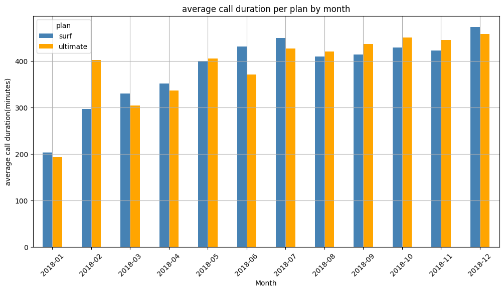

```
average call duration by plan and month:
        plan    month  total_minutes
0       surf  2018-01     203.000000
1       surf  2018-02     297.000000
2       surf  2018-03     330.000000
3       surf  2018-04     351.540000
4       surf  2018-05     399.584416
5       surf  2018-06     431.298969
6       surf  2018-07     449.983471
7       surf  2018-08     410.111111
8       surf  2018-09     414.226804
9       surf  2018-10     429.729958
10      surf  2018-11     423.325088
11      surf  2018-12     473.836478
12  ultimate  2018-01     193.500000
13  ultimate  2018-02     403.142857
14  ultimate  2018-03     304.250000
15  ultimate  2018-04     336.857143
16  ultimate  2018-05     406.241379
17  ultimate  2018-06     370.957447
18  ultimate  2018-07     427.067797
19  ultimate  2018-08     421.436620
20  ultimate  2018-09     437.511628
21  ultimate  2018-10     450.735849
22  ultimate  2018-11     445.196850
23  ultimate  2018-12     459.099338
```

```python
# Compare average duration of calls per each plan per each distinct month. Plot a bar plat to visualize it.

avg_duration_by_plan_month = user_activity.groupby(['plan', 'month'])['total_minutes'].mean().reset_index()

# pivot data for plotting

df_plot = avg_duration_by_plan_month.pivot(index='month', columns='plan', values='total_minutes')
plot = df_plot.plot(
    kind='bar',
    xlabel='Month',
    ylabel='average call duration(minutes)',
    title='average call duration per plan by month',
    figsize=(12, 6),
    color=['steelblue', 'orange'],
    grid=True,
    legend=True,
    rot=45
)
plt.show()

print('average call duration by plan and month:')
print(avg_duration_by_plan_month)
```

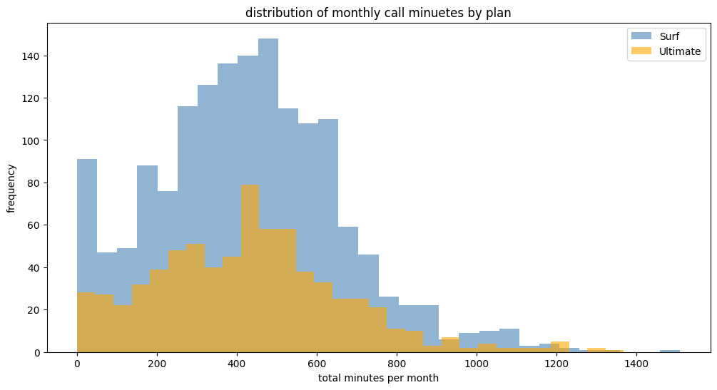

```
minutes statistics by plan:
           count        mean         std  min    25%    50%     75%     max
plan
surf      1573.0  428.749523  234.453150  0.0  272.0  425.0  576.00  1510.0
ultimate   720.0  430.450000  240.508762  0.0  260.0  424.0  565.25  1369.0
```

```python
# Compare the number of minutes users of each plan require each month. Plot a histogram.

df_minutes_surf = user_activity[user_activity['plan'] == 'surf']['total_minutes']
df_minutes_ultimate = user_activity[user_activity['plan'] == 'ultimate']['total_minutes']

# plot dataframe
num_bins = 30
alpha_value = 0.6
x_label = 'total minutes per month'
y_label = 'frequency'
title = 'distribution of monthly call minuetes by plan'

plot = plt.figure(figsize=(12, 6))
df_minutes_surf.plot(
    kind='hist',
    bins=num_bins,
    alpha=alpha_value,
    label='Surf',
    color='steelblue'
)
df_minutes_ultimate.plot(
    kind='hist',
    bins=num_bins,
    alpha=alpha_value,
    label='Ultimate',
    color='orange'
)
plt.xlabel(x_label)
plt.ylabel(y_label)
plt.title(title)
plt.legend()
plt.show()
print("\nminutes statistics by plan:")
print(user_activity.groupby('plan')['total_minutes'].describe())
```

**Reviewer's comment**

Well done — this section computes the per-plan call statistics and includes the requested bar chart and histogram. The analysis for calls is complete and clear.

[Calculate the mean and the variable of the call duration to reason on whether users on the different plans have different behaviours for their calls.]

```python
# Calculate the mean and the variance of the monthly call duration

# statistics

call_stats = user_activity.groupby('plan')['total_minutes'].agg(['mean', 'var', 'std'])
call_stats.columns = ['mean minutes', 'variance', 'std dev']

# values

surf_mean = call_stats.loc['surf', 'mean minutes']
surf_variance = call_stats.loc['surf', 'variance']
surf_std = call_stats.loc['surf', 'std dev']

ultimate_mean = call_stats.loc['ultimate', 'mean minutes']
ultimate_variance = call_stats.loc['ultimate', 'variance']
ultimate_std = call_stats.loc['ultimate', 'std dev']

print("call duration stats by plan:")
print(call_stats)
print(f"\nsurf plan:")
print(f"mean: {surf_mean: .2f} minutes")
print(f"variance: {surf_variance: .2f}")
print(f"std dev: {surf_std: .2f}")

print(f"\nultimate plan:")
print(f"mean: {ultimate_mean: .2f} minutes")
print(f"std dev: {ultimate_std: .2f}")
```

```
call duration stats by plan:
          mean minutes      variance     std dev
plan
surf        428.749523  54968.279461  234.453150
ultimate    430.450000  57844.464812  240.508762

surf plan:
mean:  428.75 minutes
variance:  54968.28
std dev:  234.45

ultimate plan:
mean:  430.45 minutes
std dev:  240.51
```

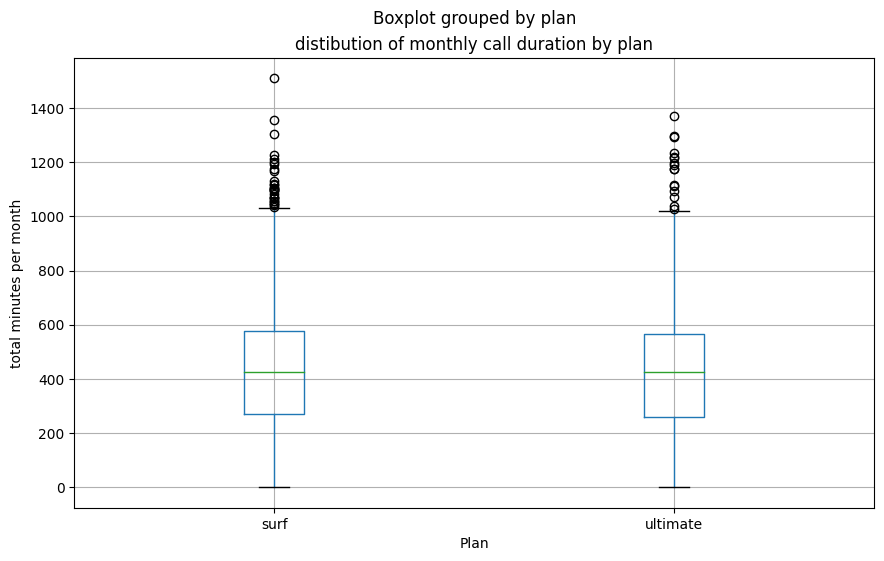

```
surf users average 428.75 minutes per month

ultimate users average 430.45 minutes per month

ultimate users talk 0.4% more than surf users

surf plan includes 500 minutes, average usage is 428.7 minutes
most surf users stay within their limit

ultimate plan includes 3000 minutes, average usage is 430.4 minutes
ultimate users stay within their limit
```

```python
# Plot a boxplot to visualize the distribution of the monthly call duration

df_boxplot = user_activity[['plan', 'total_minutes']].copy()
plot = df_boxplot.boxplot(
    column='total_minutes',
    by='plan',
    figsize=(10, 6),
    grid=True
)
plt.title('distibution of monthly call duration by plan')
plt.ylabel('total minutes per month')
plt.xlabel('Plan')
plt.show()

# concluding on calling behavior

print(f"surf users average {surf_mean:.2f} minutes per month")
print(f"\nultimate users average {ultimate_mean:.2f} minutes per month")

if ultimate_mean > surf_mean:
    pct_diff = ((ultimate_mean - surf_mean) / surf_mean) * 100
    print(f"\nultimate users talk {pct_diff:.1f}% more than surf users")
else:
    pct_diff = ((surf_mean - ultimate_mean) / ultimate_mean) * 100
    print(f"\nsurf users talk {pct_diff:.1f}% more than ultimate users")

# comparison to plan limits

surf_limit = 500
ultimate_limit = 3000

print(f"\nsurf plan includes {surf_limit} minutes, average usage is {surf_mean:.1f} minutes")
if surf_mean < surf_limit:
    print("most surf users stay within their limit")
else:
    print("surf users exceed their limit on average")

print(f"\nultimate plan includes {ultimate_limit} minutes, average usage is {ultimate_mean:.1f} minutes")
if ultimate_mean < ultimate_limit:
    print("ultimate users stay within their limit")
else:
    print("ultimate users exceed their limit on average")
```

**Reviewer's comment**

### Messages

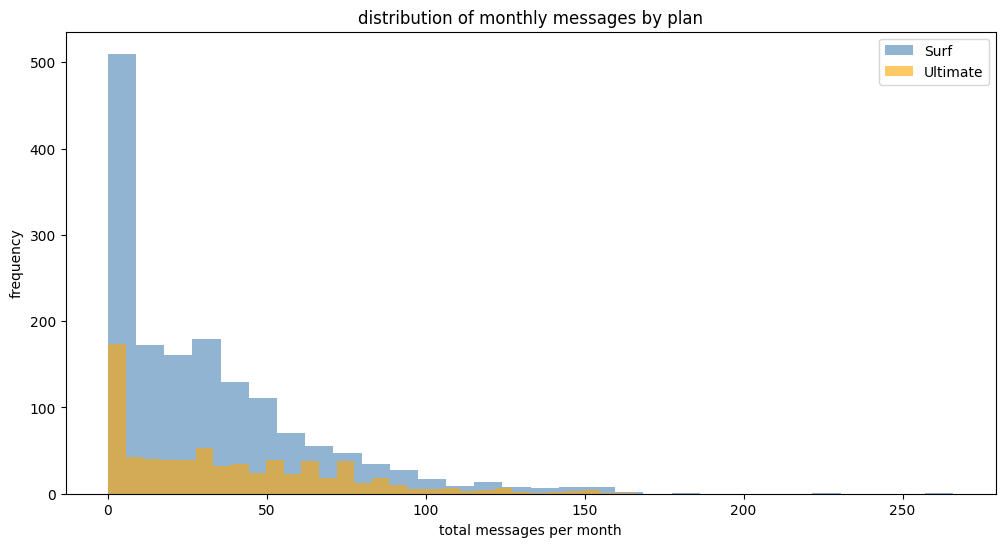

```python
# Compare the number of messages users of each plan tend to send each month

df_messages = user_activity[['plan', 'total_messages']].copy()

# parameters

num_bins=30
x_label = 'total messages per month'
y_label = 'frequency'
title = 'distribution of monthly messages by plan'

# dataframe plot

plot = plt.figure(figsize=(12, 6))

surf_data = df_messages[df_messages['plan'] =='surf']['total_messages']
ultimate_data = df_messages[df_messages['plan'] == 'ultimate']['total_messages']

surf_data.plot(kind='hist',
               bins=num_bins,
               alpha=0.6,
               label='Surf',
               color='steelblue',
               legend=True
              )
ultimate_data.plot(kind='hist',
                   bins=num_bins,
                   alpha=0.6,
                   label='Ultimate',
                   color='orange',
                   legend=True
                  )
plt.xlabel(x_label)
plt.ylabel(y_label)
plt.title(title)
plt.show()
```

```
message statistics
          mean messages     variance    std_dev
plan
surf          31.159568  1126.724522  33.566717
ultimate      37.551389  1208.756744  34.767179
```

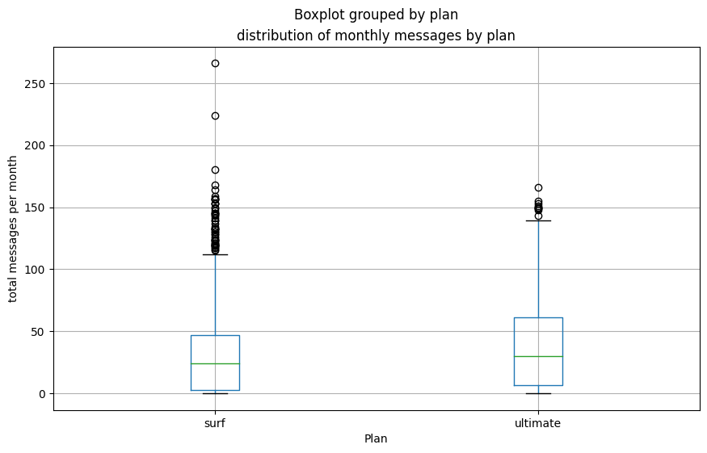

```python
# Compare the amount of internet traffic consumed by users per plan

msg_stats = user_activity.groupby('plan')['total_messages'].agg(['mean', 'var', 'std'])
msg_stats.columns = ['mean messages', 'variance', 'std_dev']

surf_msg_mean = msg_stats.loc['surf', 'mean messages']
ultimate_msg_mean = msg_stats.loc['ultimate', 'mean messages']

print("\nmessage statistics")
print(msg_stats)

df_boxplot_msg = user_activity[['plan', 'total_messages']].copy()

# parameters

y_label = 'total messages per month'
title = 'distribution of monthly messages by plan'

# dataaframe boxplot

plot = df_boxplot_msg.boxplot(column='total_messages',
                              by='plan',
                              figsize=(10, 6),
                              grid=True,)
plt.ylabel(y_label)
plt.xlabel('Plan')
plt.title(title)
plt.show()
```

```python
# concluding messaging behavior

print(f"\nsurf users send {surf_msg_mean: .2f} messages per month on average")
print(f"ultimate users send {ultimate_msg_mean: .2f} messages per month on average")

surf_msg_limit = 50
ultimate_msg_limit = 1000

print(f"\nsurf plan includes {surf_msg_limit} messages, average usage is {surf_msg_mean: .1f} messages")
print(f"ultimate plan includes {ultimate_msg_limit} messages, average usagesis {ultimate_msg_mean: .1f} messages")
```

```
surf users send  31.16 messages per month on average
ultimate users send  37.55 messages per month on average

surf plan includes 50 messages, average usage is  31.2 messages
ultimate plan includes 1000 messages, average usagesis  37.6 messages
```

**Reviewer's comment**

### Internet

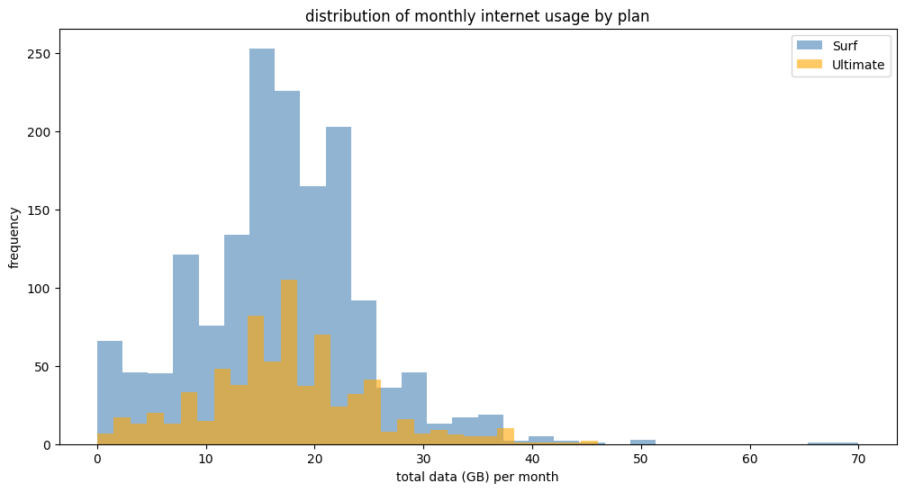

```python
df_gb_surf = user_activity[user_activity['plan'] == 'surf']['total_gb'].copy()
df_gb_ultimate = user_activity[user_activity['plan'] == 'ultimate']['total_gb'].copy()
#parameters

num_bins = 30
alpha_value = 0.6
x_label = 'total data (GB) per month'
y_label = 'frequency'
title = 'distribution of monthly internet usage by plan'

# dataframe plot

plot = plt.figure(figsize=(12, 6))

df_gb_surf.plot(kind='hist',
               bins=num_bins,
               alpha=alpha_value,
               label='Surf',
               color='steelblue',
               legend=True
              )
df_gb_ultimate.plot(kind='hist',
                   bins=num_bins,
                   alpha=alpha_value,
                   label='Ultimate',
                   color='orange',
                   legend=True
                  )
plt.xlabel(x_label)
plt.ylabel(y_label)
plt.title(title)
plt.show()
```

```
internet statistics:
            mean gb  variance   std dev
plan
surf      16.670693  61.58360  7.847522
ultimate  17.306944  58.83055  7.670108
```

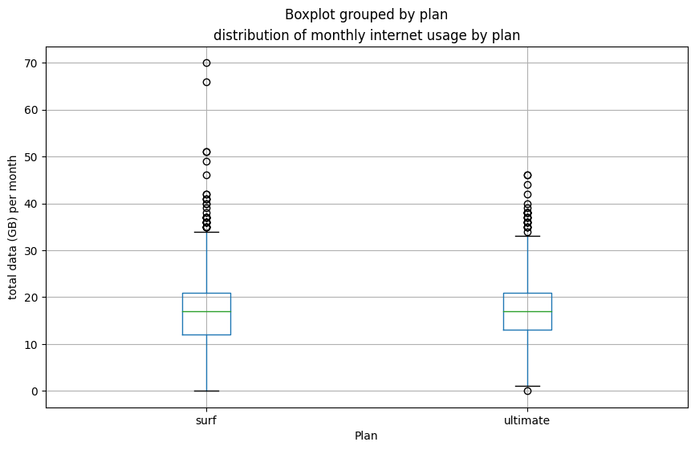

```python
# internet statistics and boxplot

internet_stats = user_activity.groupby('plan')['total_gb'].agg(['mean', 'var', 'std'])
# rename
internet_stats = internet_stats.rename(columns={
    'mean': 'mean gb',
    'var': 'variance',
    'std': 'std dev'
})


surf_gb_mean = internet_stats.loc['surf', 'mean gb']
surf_gb_variance = internet_stats.loc['surf', 'variance']
surf_gb_std = internet_stats.loc['surf', 'std dev']

ultimate_gb_mean = internet_stats.loc['ultimate', 'mean gb']
ultimate_gb_variance = internet_stats.loc['ultimate', 'variance']
ultimate_gb_std = internet_stats.loc['ultimate', 'std dev']

print(f"\ninternet statistics:")
print(internet_stats)



# boxplot parameters

df_boxplot_gb = user_activity[['plan', 'total_gb']].copy()

y_label = 'total data (GB) per month'
title = 'distribution of monthly internet usage by plan'

# internet boxplot

plot = df_boxplot_gb.boxplot(column='total_gb',
                             by='plan',
                             figsize=(10, 6),
                             grid=True
                            )
plt.ylabel(y_label)
plt.xlabel('Plan')
plt.title(title)
plt.show()
```

**Reviewer's comment**

```python
# concluding internet statistics

print(f"\n surf users consume {surf_gb_mean: .2f} GB per month on average")
print(f"ultimate users consume {ultimate_gb_mean: .2f} GB per month on average")

# differences

if ultimate_gb_mean > surf_gb_mean:
    gb_diff = ultimate_gb_mean - surf_gb_mean
    pct_diff = ((ultimate_gb_mean - surf_gb_mean) / surf_gb_mean) * 100
    print(f"\nultimateusers consume {gb_diff: .2f} GB morethan surf users")
    print(f"that's {pct_diff: .1f}% more data usage")

# comparison to limits

surf_gb_limit = 15
ultimate_gb_limit = 30

print(f"surf plan:")
print(f"included data: {surf_gb_limit} GB")
print(f" average usage: {surf_gb_mean: .1f} GB")
if surf_gb_mean > surf_gb_limit:
    exceeding = surf_gb_mean - surf_gb_limit
    print(f" users exceed limit by{exceeding: .1f} GB on average")
else:
    remaining = surf_gb_limit - surf_gb_mean
    print(f"users stay {remaining: .1f} GB under limit")

print(f"\nultimate plan")
print(f"included data: {ultimate_gb_limit} GB")
print(f" average usage: {ultimate_gb_mean: .1f} GB")
if ultimate_gb_mean > ultimate_gb_limit:
    exceeding = ultimate_gb_mean - ultimate_gb_limit
    print(f"users exceed limit by {exceeding: .1f} GB on average")
else:
    remaining = ultimate_gb_limit - ultimate_gb_mean
    print(f"users have {remaining: .1f} GB unused")

# variance

print(f"\nsurf plan variance: {surf_gb_variance: .2f}")
print(f"ultimate plan variance: {ultimate_gb_variance: .2f}")
```

```
 surf users consume  16.67 GB per month on average
ultimate users consume  17.31 GB per month on average

ultimateusers consume  0.64 GB morethan surf users
that's  3.8% more data usage
surf plan:
included data: 15 GB
 average usage:  16.7 GB
 users exceed limit by 1.7 GB on average

ultimate plan
included data: 30 GB
 average usage:  17.3 GB
users have  12.7 GB unused

surf plan variance:  61.58
ultimate plan variance:  58.83
```

## Revenue

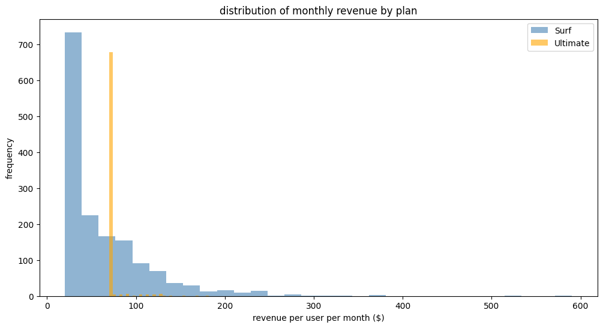

```
revenue statistics by plan:
           count       mean        std   min   25%    50%    75%     max
plan
surf      1573.0  60.706408  55.388042  20.0  20.0  40.36  80.36  590.37
ultimate   720.0  72.313889  11.395108  70.0  70.0  70.00  70.00  182.00
```

```python
df_revenue_surf = user_activity[user_activity['plan'] == 'surf']['monthly_revenue'].copy()
df_revenue_ultimate = user_activity[user_activity['plan'] == 'ultimate']['monthly_revenue'].copy()

# parameters

num_bins = 30
alpha_value = 0.6
x_label = 'revenue per user per month ($)'
y_label = 'frequency'
title = 'distribution of monthly revenue by plan'

# dataframe plot

plot = plt.figure(figsize=(12, 6))

df_revenue_surf.plot(kind='hist',
                     bins=num_bins,
                     alpha=alpha_value,
                     label='Surf',
                     color='steelblue',
                    )
df_revenue_ultimate.plot(kind='hist',
                         bins=num_bins,
                         alpha=alpha_value,
                         label='Ultimate',
                         color='orange',
                        )
plt.xlabel(x_label)
plt.ylabel(y_label)
plt.title(title)
plt.legend()
plt.show()

print("\nrevenue statistics by plan:")
print(user_activity.groupby('plan')['monthly_revenue'].describe())
```

```
revenue statistics:
               mean          var        std
plan
surf      60.706408  3067.835152  55.388042
ultimate  72.313889   129.848486  11.395108

surf plan:
mean revenue: $ 60.71
variance: $ 3067.84
std dev: $ 55.39

ultimate plan:
mean revenue: $ 72.31
variance: $ 129.85
std dev: $ 11.40
```

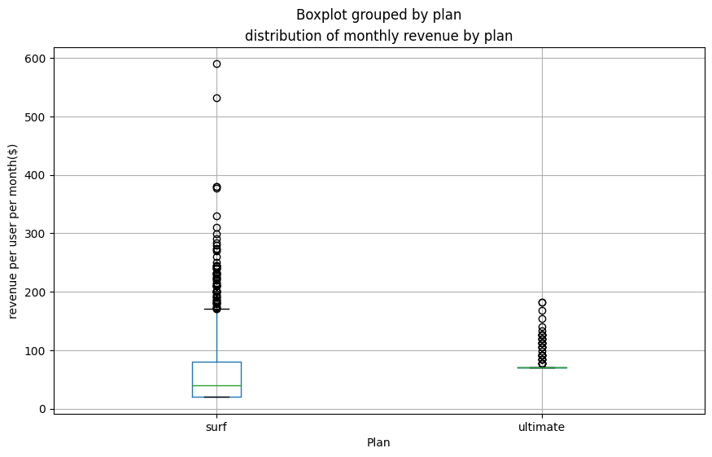

```python
# revenue statistics

revenue_stats = user_activity.groupby('plan')['monthly_revenue'].agg(['mean', 'var', 'std'])

surf_revenue_mean = revenue_stats.loc['surf', 'mean']
surf_revenue_variance = revenue_stats.loc['surf', 'var']
surf_revenue_std = revenue_stats.loc['surf', 'std']

ultimate_revenue_mean = revenue_stats.loc['ultimate', 'mean']
ultimate_revenue_variance = revenue_stats.loc['ultimate', 'var']
ultimate_revenue_std = revenue_stats.loc['ultimate', 'std']

print("revenue statistics:")
print(revenue_stats)

print(f"\nsurf plan:")
print(f"mean revenue: ${surf_revenue_mean: .2f}")
print(f"variance: ${surf_revenue_variance: .2f}")
print(f"std dev: ${surf_revenue_std: .2f}")

print(f"\nultimate plan:")
print(f"mean revenue: ${ultimate_revenue_mean: .2f}")
print(f"variance: ${ultimate_revenue_variance: .2f}")
print(f"std dev: ${ultimate_revenue_std: .2f}")

# revenue boxplot

df_boxplot_revenue = user_activity[['plan', 'monthly_revenue']].copy()

y_label = 'revenue per user per month($)'
title = 'distribution of monthly revenue by plan'

plot = df_boxplot_revenue.boxplot(
    column='monthly_revenue',
    by='plan',
    figsize=(10, 6),
    grid=True
)
plt.ylabel(y_label)
plt.xlabel('Plan')
plt.title(title)
plt.show()
```

```python
# concluding monthly revenue by plan

print(f"\nsurf plan generates ${surf_revenue_mean: .2f} per user per month on average")
print(f"ultimate plan generates ${ultimate_revenue_mean: .2f} per user per month on average")

# revenue differences by plan

if ultimate_revenue_mean > surf_revenue_mean:
    revenue_diff = ultimate_revenue_mean - surf_revenue_mean
    pct_diff = ((ultimate_revenue_mean - surf_revenue_mean) / surf_revenue_mean) * 100
    print(f"\n ultimate plan generates ${revenue_diff: .2f} more per user ({pct_diff: .1f}% higher)")
else:
    revenue_diff = surf_revenue_mean - ultimate_revenue_mean
    pct_diff = ((surf_revenue_mean - ultimate_revenue_mean) / ultimate_revenue_mean) * 100
    print(f"\nsurf plan generates ${revenue_diff: .2f} more per user ({pct_diff: .1f}% higher)")

# total revenue

surf_count = len(df_revenue_surf)
ultimate_count = len(df_revenue_ultimate)
total_surf_revenue = df_revenue_surf.sum()
total_ultimate_revenue = df_revenue_ultimate.sum()

print(f"\nsurf: {surf_count} users * ${surf_revenue_mean: .2f} = ${total_surf_revenue: .2f}")
print(f"ultimate: {ultimate_count} users * ${ultimate_revenue_mean: .2f} = ${total_ultimate_revenue: .2f}")
print(f"\ntotal monthly revenue: ${total_surf_revenue + total_ultimate_revenue: .2f}")

if total_surf_revenue > total_ultimate_revenue:
    print(f"\nsurf plan generates more total revenue")
else:
    print(f"\nultimate plan generates more total revenue")
```

```
surf plan generates $ 60.71 per user per month on average
ultimate plan generates $ 72.31 per user per month on average

 ultimate plan generates $ 11.61 more per user ( 19.1% higher)

surf: 1573 users * $ 60.71 = $ 95491.18
ultimate: 720 users * $ 72.31 = $ 52066.00

total monthly revenue: $ 147557.18

surf plan generates more total revenue
```

**Reviewer's comment**

**✅ Reviewer's comment V2**

Graphs and analysis is good.

**⚠️ Reviewer's comment V2**

A big part of being a data scientist is learning to analyse data. Using if statements to determine the output rather than human analysis makes it appear that things are being done by AI instead of by a human. It is better for your career development if you look at the data and write your analysis based on observations during this course to better prepare you for your future career.

## Test statistical hypotheses

Hypothesis Test: Ultimate vs Surf Revenue

HYPOTHESES: H0 (Null): average ultimate revenue is equal to average surf revenue H1 (Alternative): average ultimate revenue is not equal to average surf revenue

TEST CHOICE: Welch's t-test: (two-sample,unequal variances) suitable independent groups comparison no presumption of equal variances ('equal_var=False') two-tailed-test (detecting differences)

SIGNIFICANCE LEVEL: alpha = 0.05 reject H0 (Null) if p-value < 0.05

**Reviewer's comment**

```python
print(user_activity[user_activity['plan'] == 'surf']['monthly_revenue'].mean())
user_activity[user_activity['plan'] == 'ultimate']['monthly_revenue'].mean()
```

```
60.706408137317226
```

```
72.31388888888888
```

```python
# hypotheses for ultimate vs surf

# Test the hypotheses

revenue_surf = user_activity[user_activity['plan'] == 'surf']['monthly_revenue']
revenue_ultimate = user_activity[user_activity['plan'] == 'ultimate']['monthly_revenue']

alpha = 0.05

t_stat, p_value = stats.ttest_ind(revenue_surf, revenue_ultimate, equal_var=False)

if p_value < alpha:
    print(f" REJECT NULL {p_value:.6f} < {alpha})")
    print(f"\ndifference between average monthly revenue by plan is statistically significant")
else:
    print(f"FAILED REJECTION of NULL (p-value = {p_value:.6f} >= {alpha})")
    print(f"Reason to presume no statistical significance between average monthly revenue by plan")
```

```
 REJECT NULL 0.000000 < 0.05)

difference between average monthly revenue by plan is statistically significant
```

Hypothesis Test: NY-NJ vs Other Regions

HYPOTHESES: H0 (Null): average NY-NJ revenue is equal to average revenue of other regions (no regional difference) H1 (Alternative): average NY-NJ revenue is not equal to average revenue of other regions (regional revenue differs)

TEST CHOICE: welch's t-test: (two-sample, unequal variances) suitable independent regional groups comparison two-tailed test to detect any differences

SIGNIFICANCE LEVEL: alpha = 0.05

**Reviewer's comment**

```python
# Test the hypotheses

ny_nj_cities = ['New York-Newark-Jersey City, NY-NJ-PA']

user_activity_with_region = user_activity.merge(
    users[['user_id', 'city']],
    on='user_id',
    how='left'
)
user_activity_with_region['region'] = user_activity_with_region['city'].apply(
    lambda x: 'NY-NJ' if 'NY-NJ'in str(x) else 'Other'
)

revenue_ny_nj = user_activity_with_region[user_activity_with_region['region'] == 'NY-NJ']['monthly_revenue']
revenue_other = user_activity_with_region[user_activity_with_region['region'] != 'NY-NJ']['monthly_revenue']

alpha = 0.05

stat, p_value = stats.ttest_ind(revenue_ny_nj, revenue_other, equal_var=False)

if p_value < alpha:
    print(f"\nREJECT NUMM (p < {alpha}): average revenue between NY-NJ and others is significantly different")
else:
    print(f"\nFAILED TO REJECT NULL (p >= {alpha}): no significant difference between average revenue by NY-NJ users and others")
```

```
REJECT NUMM (p < 0.05): average revenue between NY-NJ and others is significantly different
```

**✅ Reviewer's comment V2**

The tests look good!

## General conclusion

Which Plan Generates More Revenue?

PER-USER REVENUE: ultimate plan generates significantly more revenue per user than the surf plan statistical testing confirms that the difference in per-user revenue that the ultimate plan makes is significant

SUPPORTING FINDINGS: ultimate users pay higher base monthly fees ultimate and surf plans generate exceeding limits revenuesfrom different sources

**Reviewer's comment**

The General conclusion section doesn't include a clear, direct answer to the main question — state explicitly which plan brings more revenue (per-user and/or total) and the main reasons/assumptions that support that conclusion.

```python
print('KEY ASSUMPTIONS:')
print('\ndata processing:\nmonthly aggregation per user,\noutliers kept,\ntables merged by user_id')
print('\nANALYSIS:\ndescriptive statitstics: mean, variance, std\ntwo-sample t-tests, alpha = 0.05')
print('\nBUSINESS ASSUMPTIONS:\nrate charges apply to started excess usage(rounded)')
print('\nMAIN FINDINGS:\nultimate users consume more across all metrics\nsurf users on average stay within message limits')
print('\nRECOMMENDED:\nretention models prompting upgrading heavy surf users')
```

```
KEY ASSUMPTIONS:

data processing:
monthly aggregation per user,
outliers kept,
tables merged by user_id

ANALYSIS:
descriptive statitstics: mean, variance, std
two-sample t-tests, alpha = 0.05

BUSINESS ASSUMPTIONS:
rate charges apply to started excess usage(rounded)

MAIN FINDINGS:
ultimate users consume more across all metrics
surf users on average stay within message limits

RECOMMENDED:
retention models prompting upgrading heavy surf users
```

**Reviewer's comment**

```python
print("""MESSAGE BEHAVIOR:

ultimate users send more messages on average than surf users
ultimate and surf users typically stay within their respective message allowances
surf users average ~31 messages, well within their 50 message limit
ultimate users typically fall well within their 1000 message limit""")
```

```
MESSAGE BEHAVIOR:

ultimate users send more messages on average than surf users
ultimate and surf users typically stay within their respective message allowances
surf users average ~31 messages, well within their 50 message limit
ultimate users typically fall well within their 1000 message limit
```

**⚠️ Reviewer's comment V2**

Please use markdown cells in the future for your conclusions and analysis.